# BUGS

Muhammad Al Fatah

6/10/2021

**Catatan : Kodingan ini untuk memenuhi tugas simdat, kemungkinan banyak kesalahan. Mohon dimaklumi**

# BUGS

## Contoh BUGS (1)

Diketahui pengamatan $x_{1}, x_{2}, \dots, x_{n}$, mengikuti model eksponensial $p(x|a,b)= ab \ esp(-abx); x>0;a,b>0$ dengan prior:

$$\begin{align*}
p(a,b)= exp(-a -b); a,b>0
\end{align*}$$

Estimasi parameter $a$ dan $b$ Catatan: data dibangkitkan dengan perintah

```r
set.seed(123)
data <- rexp(100,4*5)
```

Jawab:

```r
model<-"model
    {for (i in 1:n)
      {y[i]~dexp(a*b)
    }
a~dexp(1)
b~dexp(1)
}"
```

```r
library(runjags)
n<-length(data)
y<-list(y=as.vector(data),n=n)

inits<-list(list(a=2,b=2),
            list(a=3,b=3))

results <- run.jags(model=model, monitor=c("a", "b"),
                    data=y, n.chains=2, method="rjags", inits=inits)
```

```
## Compiling rjags model...
## Calling the simulation using the rjags method...
## Note: the model did not require adaptation
## Burning in the model for 4000 iterations...
## Running the model for 10000 iterations...
## Simulation complete
## Calculating summary statistics...
## Calculating the Gelman-Rubin statistic for 2 variables....
## Finished running the simulation
```

```r
summary(results)
```

```
##    Lower95   Median  Upper95     Mean       SD Mode      MCerr MC%ofSD SSeff
## a 1.927707 4.280009 7.522458 4.506195 1.539185   NA 0.04935820     3.2   972
## b 2.063977 4.312548 7.748305 4.558713 1.557610   NA 0.05061932     3.2   947
##       AC.10     psrf
## a 0.3893255 1.000175
## b 0.3907007 1.000232
```

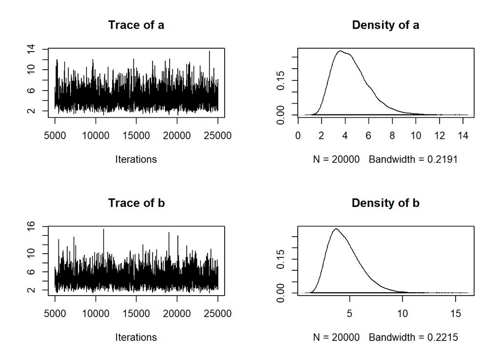

```r
library(coda)
mcresult<-as.mcmc(results)
plot(mcresult)
```

## Contoh BUGS (2)

Diketahui
$$\begin{align*}
X_i & \sim {\sf Normal}(\theta,\sigma^2), i = 1,\dots,n \\
\theta & \sim {\sf Normal} (\theta_0,\tau^2), \\
\sigma^2 & \sim {\sf IG} (a,b) \\
\end{align*}$$

Catatan: IG adalah Invers Gamma. Jika $\sigma^2$ berdistribusi Invers Gamma, berarti $1/\sigma^2$ berdistribusi gamma. Estimasi parameter $\theta$ dan $\sigma$.

$a,b,\theta_0,\tau$ adalah hiperparameter yang nilainya ditentukan Kita pakai:

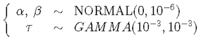

$\theta_0=0$ $\tau^2=1/10^{-6}=10^6$ $a,b=10^-3$

Jawab:

```r
model<-"model
    {for (i in 1:n)
{y[i]~dnorm(mu, tau)
}
tau~dgamma(1.0E-3,1.0E-3)
mu ~ dnorm(0, 1.0E-6)
sigma <- 1/sqrt(tau)
}"
```

```r
library(runjags)
set.seed(123)
data <- rnorm(150, 7, 16)
n<-length(data)
y<-list(y=as.vector(data),n=n)

inits<-list(list(mu = 25, tau = 10),
            list(mu = 30, tau = 11))
results <- run.jags(model=model, monitor=c("mu", "sigma"),
                    data=y, n.chains=2, method="rjags", inits=inits)
```

```
## Compiling rjags model...
## Calling the simulation using the rjags method...
## Note: the model did not require adaptation
## Burning in the model for 4000 iterations...
## Running the model for 10000 iterations...
## Simulation complete
## Calculating summary statistics...
## Calculating the Gelman-Rubin statistic for 2 variables....
## Finished running the simulation
```

```r
summary(results)
```

```
##         Lower95    Median   Upper95      Mean        SD Mode       MCerr
## mu     4.175462  6.604865  9.049421  6.606238 1.2508472   NA 0.008844826
## sigma 13.546435 15.234788 17.010334 15.273314 0.8920612   NA 0.006307825
##       MC%ofSD SSeff         AC.10      psrf
## mu        0.7 20000  5.329883e-03 1.0000518
## sigma     0.7 20000 -9.327593e-05 0.9999623
```

```r
thetab1 <- as.mcmc(results)

summary(thetab1)
```

```
##
## Iterations = 5001:25000
## Thinning interval = 1
## Number of chains = 1
## Sample size per chain = 20000
##
## 1. Empirical mean and standard deviation for each variable,
##    plus standard error of the mean:
##
##         Mean     SD Naive SE Time-series SE
## mu     6.606 1.2508 0.008845       0.008845
## sigma 15.273 0.8921 0.006308       0.006308
##
## 2. Quantiles for each variable:
##
##         2.5%    25%    50%    75%  97.5%
## mu     4.184  5.764  6.605  7.446  9.063
## sigma 13.640 14.655 15.235 15.838 17.135
```

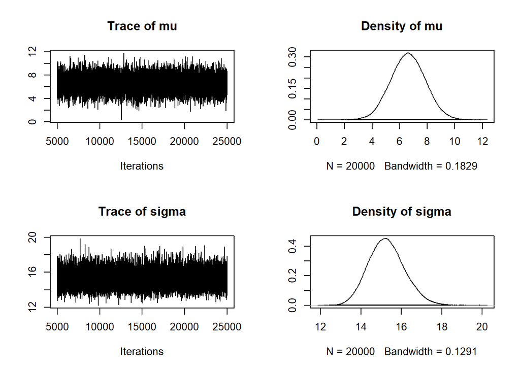

```r
plot(thetab1)
```

Kemudian jika kita lihat dari plot tracenya sudah seperti ulat bulu gemuk yang berarti bisa diasumsikan konvergen.

### Uji Geweke

```r
geweke.diag(thetab1)
```

```
##
## Fraction in 1st window = 0.1
## Fraction in 2nd window = 0.5
##
##      mu   sigma
##  0.5634 -1.1371
```

Berdasarkan dari uji Geweke, nilai Z dari kedua variabel tersebut ada diantara -1.96 sampai 1.96 yang berarti konvergen.

### Uji Raftery

```r
raftery.diag(thetab1)
```

```
##
## Quantile (q) = 0.025
## Accuracy (r) = +/- 0.005
## Probability (s) = 0.95
##
##        Burn-in  Total Lower bound  Dependence
##        (M)      (N)   (Nmin)       factor (I)
##  mu    2        3771  3746         1.01
##  sigma 2        3849  3746         1.03
```

Dari hasil uji Raftery, iterasi yang dilakukan sudah cukup karena minimal diperlukan sebanyak 3 ribuan iterasi dan ternyata nilai I-nya mendekati 1 yang berarti independen.

### Uji Heidel

```r
heidel.diag(thetab1)
```

```
##
##       Stationarity start     p-value
##       test         iteration
## mu    passed       1         0.934
## sigma passed       1         0.633
##
##       Halfwidth Mean  Halfwidth
##       test
## mu    passed     6.61 0.0173
## sigma passed    15.27 0.0124
```

Untuk uji Heidel didapatkan semuanya passed yang berarti stasioner.

### Uji Gelman

```r
gelman.diag(results)
```

```
## Potential scale reduction factors:
##
##       Point est. Upper C.I.
## mu             1          1
## sigma          1          1
##
## Multivariate psrf
##
## 1
```

jika kita uji Gelman, hasil dari batas atasnya adalah 1 yang berarti sudah stasioner.

## Contoh BUGS (3)

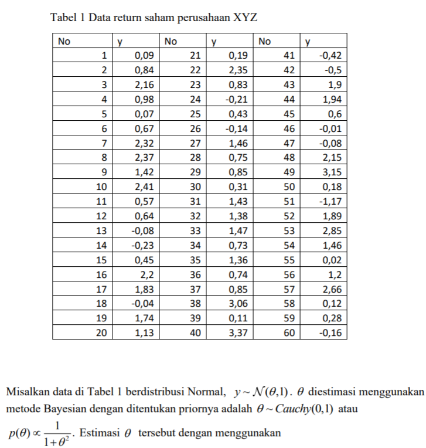

catatan: Distribusi Cauchy sama dengan distribusi Student t dengan derajat bebasnya adalah 1.

Jawab:

```r
model1 <- "model{
 for (i in 1:n){
 y[i] ~ dnorm(theta, 1)
 }
 theta ~ dt(0, 1, 1)
}"
```

### Menjalankan Code

```r
library(runjags)
data<-read.csv2("data/quiz.csv")
data<-data[,2]
n <- length(data)
y <- list(y = as.vector(data), n = n)
inits <- list(list(theta = 0),
              list(theta = 0.5))
thetabb <- run.jags(model = model1, monitor = c("theta"),
                    data = y, n.chains = 2, method = "rjags", inits = inits
)
```

```
## Compiling rjags model...
## Calling the simulation using the rjags method...
## Adapting the model for 1000 iterations...
## Burning in the model for 4000 iterations...
## Running the model for 10000 iterations...
## Simulation complete
## Calculating summary statistics...
## Calculating the Gelman-Rubin statistic for 1 variables....
## Finished running the simulation
```

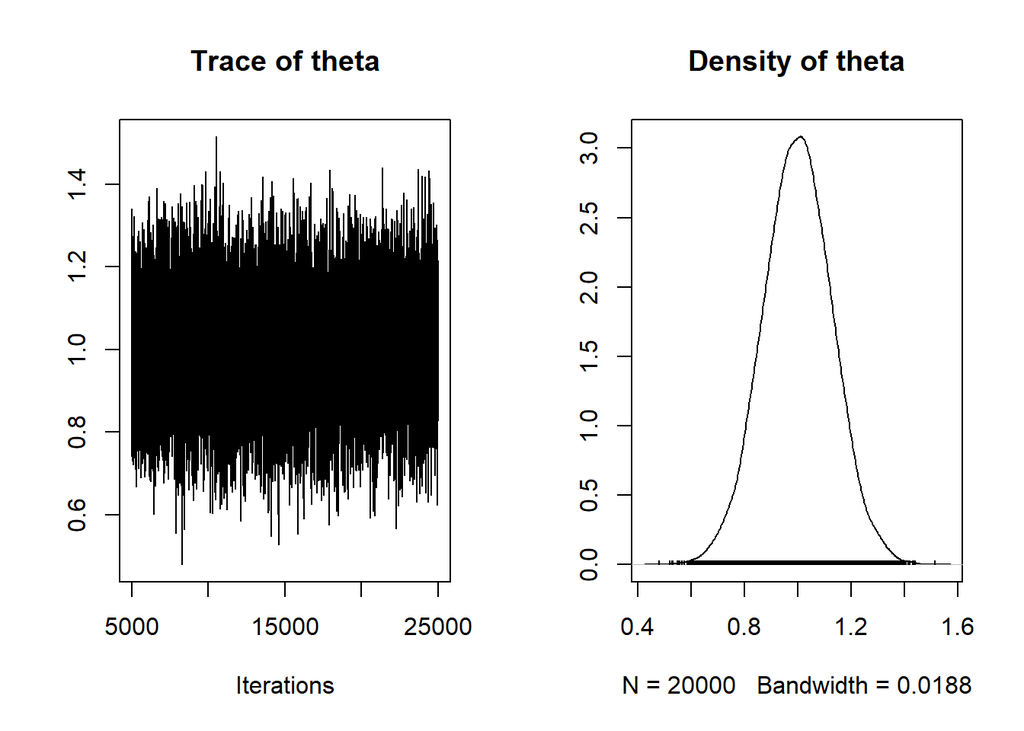

```r
thetabmcb <- as.mcmc(thetabb)
plot(thetabmcb)
```

Jika dilihat dari plotnya, sudah bisa dikatakan bahwa sudah konvergen.

### Uji Geweke

```r
geweke.diag(thetabmcb)
```

```
##
## Fraction in 1st window = 0.1
## Fraction in 2nd window = 0.5
##
##  theta
## 0.6102
```

### Uji Raftery

```r
raftery.diag(thetabmcb)
```

```
##
## Quantile (q) = 0.025
## Accuracy (r) = +/- 0.005
## Probability (s) = 0.95
##
##        Burn-in  Total Lower bound  Dependence
##        (M)      (N)   (Nmin)       factor (I)
##  theta 5        6184  3746         1.65
```

Dari hasil uji Raftery, nilai I-nya di sekitar 1 sampai 2 (kurang tau ya, ini masuknya independen atau dependen).

### Uji Heidel

```r
heidel.diag(thetabmcb)
```

```
##
##       Stationarity start     p-value
##       test         iteration
## theta passed       1         0.524
##
##       Halfwidth Mean Halfwidth
##       test
## theta passed    1    0.00233
```

Untuk uji Heidel didapatkan semuanya passed yang berarti stasioner.

### Uji Gelman

```r
gelman.diag(thetabb)
```

```
## Potential scale reduction factors:
##
##       Point est. Upper C.I.
## theta          1          1
```

jika kita uji Gelman, hasil dari batas atasnya adalah 1 yang berarti sudah stasioner.

## Contoh BUGS (4)

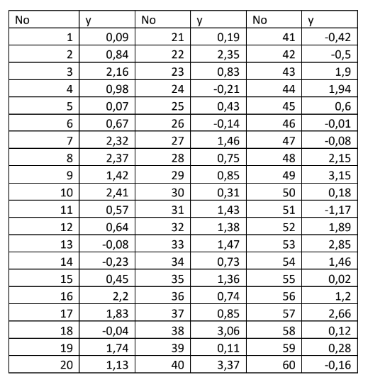

Misalkan data di atas berdistribusi Normal, $y \sim N(\mu,\sigma^2)$. $\mu$ dan $\sigma^2$ diestimasi menggunakan metode Bayesian dengan ditentukan priornya adalah $\mu \sim Normal(m,s^2)$ dan $\sigma^{-2} = \tau \sim Gamma(a,b)$. Estimasi $\mu$ dan $\sigma^2$

Jawab:

```r
model2 <- "model{
 for (i in 1:n){
 y[i] ~ dnorm(mu, tau)
 }
 mu ~ dnorm(0, 1.0E-6)
 tau ~ dgamma(1.0E-3, 1.0E-3)
 sig2 <- 1/tau
}"

library(runjags)
n <- length(data)
y <- list(y = as.vector(data), n = n)
inits <- list(list(mu = 0, tau = 1),
              list(mu = 0.5, tau = 1.1))

thetab2 <- run.jags(model = model2, monitor = c("mu", "sig2"),
                    data = y, n.chains = 2, method = "rjags", inits = inits
)
```

```
## Compiling rjags model...
## Calling the simulation using the rjags method...
## Note: the model did not require adaptation
## Burning in the model for 4000 iterations...
## Running the model for 10000 iterations...
## Simulation complete
## Calculating summary statistics...
## Calculating the Gelman-Rubin statistic for 2 variables....
## Finished running the simulation
```

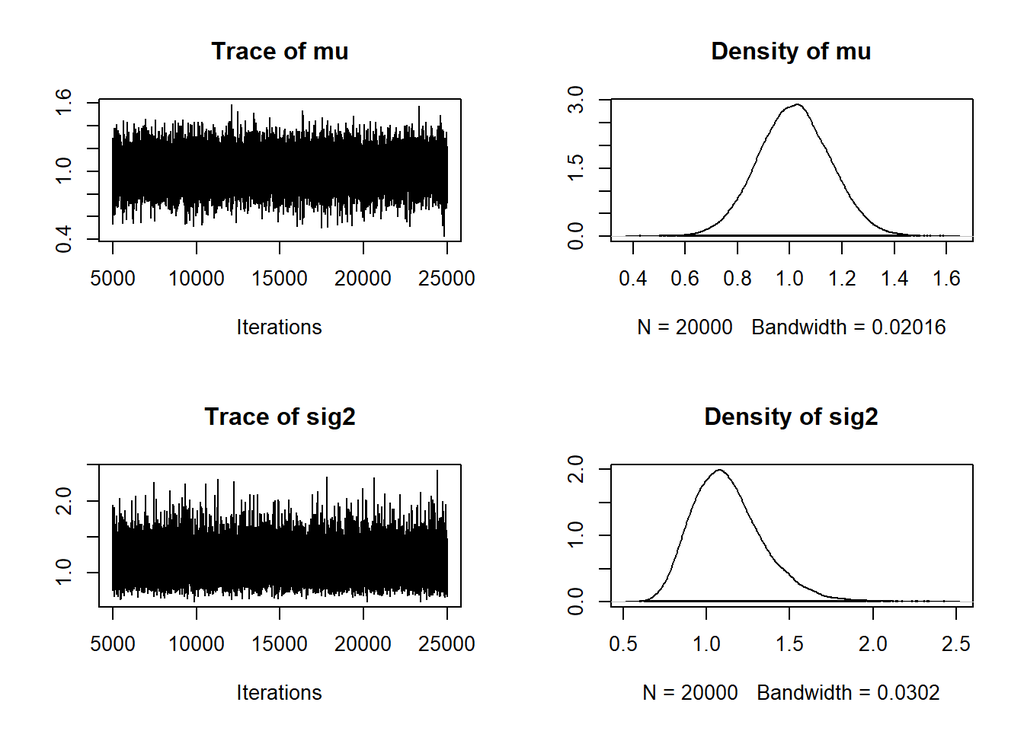

```r
thetabmcb2 <- as.mcmc(thetab2)
plot(thetabmcb2)
```

Jika dilihat dari plotnya, sudah bisa dikatakan bahwa sudah konvergen.

### Uji Geweke

```r
geweke.diag(thetabmcb2)
```

```
##
## Fraction in 1st window = 0.1
## Fraction in 2nd window = 0.5
##
##      mu    sig2
##  0.4598 -0.1920
```

Berdasarkan dari uji Geweke, nilai Z dari kedua variabel tersebut ada diantara -1.96 sampai 1.96 yang berarti konvergen.

### Uji Raftery

```r
raftery.diag(thetabmcb2)
```

```
##
## Quantile (q) = 0.025
## Accuracy (r) = +/- 0.005
## Probability (s) = 0.95
##
##       Burn-in  Total Lower bound  Dependence
##       (M)      (N)   (Nmin)       factor (I)
##  mu   2        3865  3746         1.03
##  sig2 2        3710  3746         0.99
```

Dari hasil uji Raftery, nilai I-nya mendekati 1, dapat dikatakan variabelnya independen.

### Uji Heidel

```r
heidel.diag(thetabmcb2)
```

```
##
##      Stationarity start     p-value
##      test         iteration
## mu   passed       1         0.890
## sig2 passed       1         0.603
##
##      Halfwidth Mean Halfwidth
##      test
## mu   passed    1.02 0.00191
## sig2 passed    1.13 0.00304
```

Untuk uji Heidel didapatkan semuanya passed yang berarti stasioner.

### Uji Gelman

```r
gelman.diag(thetab2)
```

```
## Potential scale reduction factors:
##
##      Point est. Upper C.I.
## mu            1          1
## sig2          1          1
##
## Multivariate psrf
##
## 1
```

jika kita uji Gelman, hasil dari batas atasnya adalah 1 yang berarti sudah stasioner.